# QPC

Sophie Buysse

2024-02-27

The goal of this Code is to use the R package Quaint to differentiation between direct selection and indirect selection on stamen loss in the pyrenees.

# Install the Package

only need to do this once. Copied directly from the Quaint Github page. (https://github.com/emjosephs/quaint/blob/master/install_quaint.R)

This code currently doesn’t work for me, so I’m going to try just coping Emily’s functions instead?

```r
packages_needed <- c("devtools","roxygen2")

for (i in 1:length(packages_needed)){
  if(!(packages_needed[i] %in% installed.packages())){install.packages(packages_needed[i])}
}

for (i in 1:length(packages_needed)){
  library( packages_needed[i], character.only = TRUE)
}


document(pkg = "../")
setwd('../')
install('quaint')
```

# Set up Quaint Functions

calcQpc

```r
#' Calculate Qpc
#'
#' This function calculates Qpc given data about the relatedness matrix, and a set of trait values
#' @param myZ vector of traits. Not normalized yet.
#' @param myU matrix of eigenvectors of the kinship matrix (each column is an eigenvector)
#' @param myLambdas vector of eigenvalues of the kinship matrix
#' @param myM the range of PCs you want to test for selection
#' @param myL the range of PCs used to estimate Va
#' @export
#' @examples
#' calcQpc()

calcQpc <- function(myZ, myU, myLambdas, myL, myM){
  myZ = myZ[1:dim(myU)[1]] - mean(myZ) #mean center phenotypes
  myCmM = (myZ %*% myU[,myM])/sqrt(myLambdas[myM]) #project + standardize by the eigenvalues for testing for selection
  myCmL = (myZ %*% myU[,myL])/sqrt(myLambdas[myL]) #project + standardize by the eigenvalues for estimating Va
  myQm = sapply(myM, function(n){var0(myCmM[n])/var0(myCmL) })  #test for selection
  myPs = sapply(myM, function(x){pf(myQm[x], 1, length(myL), lower.tail=F)}) #get a pvalue
  retdf = list(cm = myCmM, cml = myCmL, qm = myQm, pvals = myPs)
  return(retdf)
  }
```

condQpc

```r
#' Calculate conditional Qpc
#'
#' This function calculates Qpc given data about the relatedness matrix, and a set of trait values
#' @param myZ two columned data frame containing vectors of two traits. Not normalized yet. The first trait is the one we're testing for selection on conditional on the second trait.
#' @param myU matrix of eigenvectors of the kinship matrix (each column is an eigenvector)
#' @param myLambdas vector of eigenvalues of the kinship matrix
#' @param myM the range of PCs you want to test for selection
#' @param myL the range of PCs used to estimate Va
#' @export
#' @examples
#' calcQpc()

condQpc <- function(myZ,myU, myLambdas, myM, myL){

  # get Xms for each PC (for Z1, the focal trait and Z2, the correlated trait) THESE ARE MEAN CENTERED
  myX1centered = (myZ[-nrow(myZ),1]-mean(myZ[,1]))%*%myU/sqrt(myLambdas)
  myX2centered = (myZ[-nrow(myZ),2]-mean(myZ[,2]))%*%myU/sqrt(myLambdas)

  #get mu' for each PC
  Ca12 = sum(myX1centered[myL]*myX2centered[myL])/length(myL) #is this the right way to do this??
  Va2 = (sum(myX2centered[myL]^2))/length(myL)
  Va1 = sum(myX1centered[myL]^2)/length(myL)
  mu1cond = mean(myZ[-nrow(myZ),1]) + (Ca12/Va2)*(myZ[-nrow(myZ),2] - mean(myZ[,2])) #one value for each individual
  va1cond = Va1 - (Ca12^2)/Va2

  #now test for selection
  myQ = ((myZ[-nrow(myZ),1]-mu1cond)%*%myU[,myM])/sqrt(myLambdas[myM]*va1cond) #get a vector of the projections that we'll test
  #under neutrality, my Q ~ N(0,1)
  return(myQ)
}
```

make_k

```r
#' Kinship matrix function for complete data using the estimated variance across all loci
#'
#' This function makes a kinship matrix using the cov function. It standardizes by the estimated genic variance across all loci, not each locus individually
#' @param myG matrix where the rows are individuals/populations and the columns are loci and the values are the allele frequency (not the # of copies present in an individual!!!).
#' @export


make_k <- function (myG)
{
  scaleFactor = sqrt(mean(colMeans(myG) * (1 - colMeans(myG))))
    myM = dim(myG)[1]
    myT = matrix(data = -1/myM, nrow = myM - 1, ncol = myM)
    diag(myT) = (myM - 1)/myM
    myGstand = (myT %*% myG)/scaleFactor
    myK = cov(t(myGstand))
    return(myK)
}
```

var0

```r
#' Calculate variance where the mean is set to zero
#'
#' This function takes a string of numbers and calculates the variance of these numbers, assuming that the mean is 0.
#' @param x a string of vectors
#' @export


var0 <- function(x){  #variance where mean is set to 0
return(sum(x^2)/length(x))
}
```

# load other packages

```r
library(viridis)
```

```r
library(ggplot2)
```

# load data

```r
# start with example data?
load("C:/Users/Sophie/Downloads/1001-matrix-50Ksamp.rda") # called myGt
allData <- read.csv("C:/Users/Sophie/Downloads/1001genomes-FT10-FT16 and 1001genomes-accessions.csv", stringsAsFactors = F)
# get rid of missing phenotype data
allDataFT16 = dplyr::filter(allData, is.na(FT16_mean) == FALSE)

# pull out genotype data for individuals with phenotypes
combinedData = dplyr::inner_join(allDataFT16, myGt, by='id')
myG = combinedData[,-c(1:17)]
myTraits = combinedData[,1:17]

# need to replicate myG for the genotype matrix
```

```r
# my data!
# load in my data - I think this is actually the wrong data. I want the numeric format data not the letter format data.
# genotype Matrix of 50K randomly chosen sites (see 10_QpcPrep)
load("data/GenotypeMatrix_Cent_50k_Nov2023.ROBJ") # called Stamen_Gt_sub
load("data/RawPhenotypes_Aug2023.ROBJ") # called pheno2
# don't have any missing phenotype data to get rid of

# let's join geno and pheno together quickly
stamenCombined <- dplyr::inner_join(Stamen_Gt_sub, pheno2, by = 'LineID')
# make stamenG to use for make_k
stamenG <- stamenCombined[ , c(2:50001)]
# make list of phenotype, basically replicates pheno2 but this way I know the orders will be the same with the geno matrix
stamenTrait <- stamenCombined[ , c(1, 50002)]
```

Note: later on I think I might want to add elevation in to this too to use in a coloring scheme to make graphs, but let’s skip that for now. Adding that in on 11/20/2023

# make a kinship matrix

I got a kinship matrix from gemma. why am I not using that here? Shouldn’t I be using whatever was input in to plink to do PCA initially? Yes I want the same input. Can’t reuse anything because I need there to be no NAs and I need to make sure the standardization is done a certain way for the kinship matrix for the later Qpc math to work. The input file I used in the Qpc prep Rscript is the same input file used for Fst, PCA, and GWAS so there is that consistency.

```r
# example data
myK <- make_k(as.matrix(myG))
# do eigen decomposition
myEig <- eigen(myK)

# plot the first two PCs
plot(myEig$vectors[,1], myEig$vectors[,2], bty="n", xlab = "PC1", ylab = "PC2", col = '#FF5300')

# plot pve
plot(myEig$values/sum(myEig$values)*100, col = "#43B629", bty="n", ylab = "% variation explained by each PC", xlab = "PC")
```

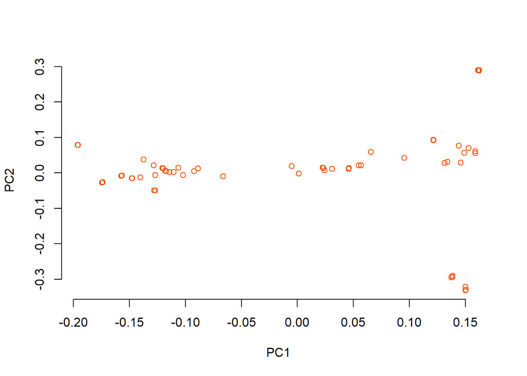

```r
# Stamen Data
stamenK <- make_k(as.matrix(stamenG))
# do eigen decomposition
stamenEig <- eigen(stamenK)

# plot the first two PCs
plot(stamenEig$vectors[,1], stamenEig$vectors[,2], bty="n", xlab = "PC1", ylab = "PC2", col = '#FF5300')
```

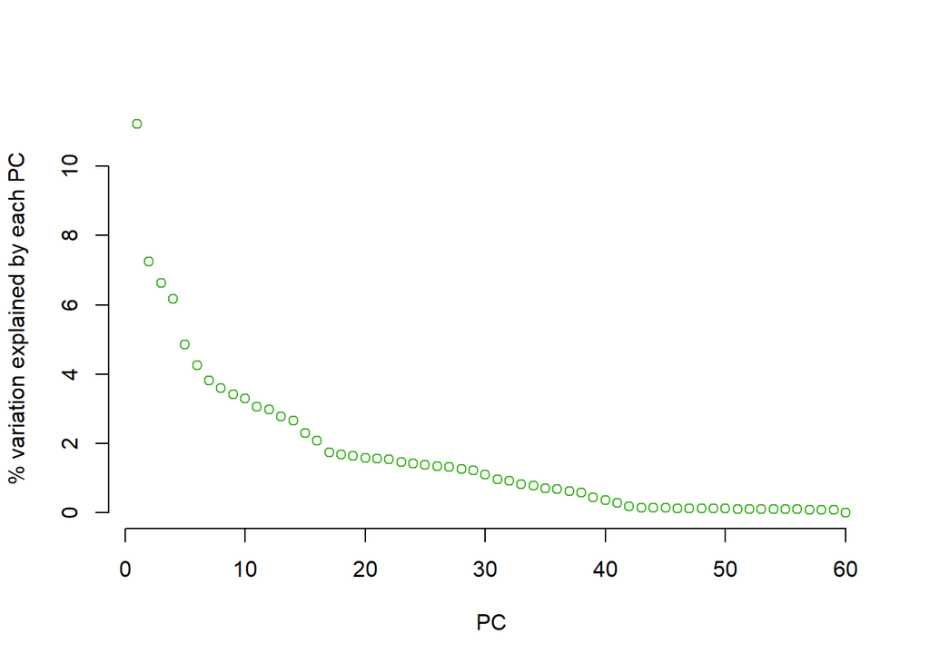

```r
# this looks different than the PCA I made with plink, likely just because the standardization is different??

# plot pve
plot(stamenEig$values/sum(stamenEig$values)*100, col = "#43B629", bty="n", ylab = "% variation explained by each PC", xlab = "PC")
```

```r
# PVE of PCs
stamenEig$values/sum(stamenEig$values)*100
```

```
##  [1] 11.21262931  7.25831592  6.63478167  6.17703836  4.86215615  4.26632860
##  [7]  3.81904277  3.59466508  3.41326637  3.29730306  3.06618623  2.96974567
## [13]  2.77885965  2.66032733  2.29585063  2.07373916  1.73585042  1.67579624
## [19]  1.64899494  1.58906195  1.56627433  1.53673426  1.46366143  1.43022081
## [25]  1.37389824  1.33504720  1.33042579  1.27220241  1.22791571  1.11105832
## [31]  0.95827478  0.92796018  0.83076850  0.77508004  0.71357385  0.68694291
## [37]  0.61743101  0.58014871  0.43951485  0.35578941  0.29178110  0.17652765
## [43]  0.15545739  0.14929073  0.13833625  0.13019774  0.12879533  0.12365012
## [49]  0.12026675  0.11815044  0.11483401  0.11242937  0.10774781  0.10619610
## [55]  0.10425818  0.10054799  0.08999405  0.08772217  0.07864427  0.00231033
```

Using the PVE plot, I am going to choose the first 4 PCs to use to look for a signal of selection. Emily suggested using the ones that are correlated with elevation so maybe this will change later on but starting with 4 because there is a break in the pve after 4.

Then I use the bottom half of the PCs to estimate Va (additive variation) so that is PC 30-60 - estimates the drift part.

# Run Qpc

myZ is a vector of trait values myU is the eigen vectors of the kinship matrix myLambdas is the eigen values of the kinship matrix myL is the range of PCs used to estimate Va myM is the range of PCs used to test for selection

Questions: How do you choose the PCs to use to estimate Va and the PCs to use to test for selection? Emily chooses from the plots of the eigen values to decide which ones to test. Since I am interested in elevation, I should pick a PC that matches altitude (how do I do that??) and then use the bottom 50% to estimate Va

```r
# example data
myQpc <- calcQpc(myZ = myTraits$FT16_mean,
                 myU = myEig$vectors,
                 myLambdas = myEig$values,
                 myM = 1:10,
                 myL = 485:969)
```

```r
# stamen data
stamenQpc <- calcQpc(myZ = stamenTrait$Pheno,
                 myU = stamenEig$vectors,
                 myLambdas = stamenEig$values,
                 myM = 1:4,
                 myL = 30:60)
```

# look at the Qpc output

These are the types of graphs Emily made. I might want to make more, and I might want to plot them with ggplot to be consistent with other graphs I’ve made previously.

```r
# example data
plot(-log10(myQpc$pvals), bty="n", xlab = "PCs", ylab = "-log10(p value)", col = "#1BB6AF", lwd=2, xaxt="n")
abline(h = -log10(0.05/length(myQpc$pvals)), col = "#FF5300", lwd=2)
axis(1, at = c(1:length(myQpc$pvals)))
```

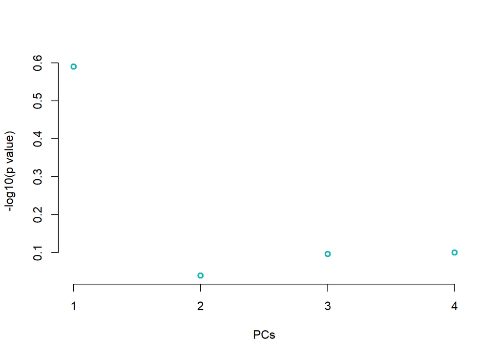

```r
# stamen data
plot(-log10(stamenQpc$pvals), bty="n", xlab = "PCs", ylab = "-log10(p value)", col = "#1BB6AF", lwd=2, xaxt="n")
abline(h = -log10(0.05/length(stamenQpc$pvals)), col = "#FF5300", lwd=2)
axis(1, at = c(1:length(stamenQpc$pvals)))
```

plot of specific PCs colored by subpopulation. Confidence intervals are just for plotting b/c based on linear models but the actual test is not linear

```r
# example data
#estimate the confidence intervals
myVaest = var0(myQpc$cml)
myCI = 1.96*sqrt(myVaest*myEig$values)

#plot
palette(c('white','#999999', '#E69F00', '#56B4E9', "#009E73", "#F0E442", "#0072B2", "#D55E00", "#CC79A7", 'black', 'mediumpurple3'))
par(mar = c(5,8,5,14), xpd=T)

plot(myEig$vectors[,2], myTraits$FT16_mean[-nrow(myTraits)], bty="n", col = as.factor(myTraits$group), lwd=2, ylab = "", yaxt="n",xlab = "PC2", cex.lab=2, cex.axis=2, xaxt="n")
axis(1, cex.axis=1.5, lwd=2)
axis(2, las=2, cex.axis=1.5, lwd=2)
mtext('Flowering time 16C',side=2, line=5, cex=2)
legend(0.06, 130, levels(as.factor(myTraits$group)), pch=1, pt.lwd = 2,col = palette(), bty="n", text.width = 0.04)
par(xpd=F)
abline(lm(myTraits$FT16_mean[-nrow(myTraits)]~myEig$vectors[,2]), lwd=2, col = "#0072B2")
abline(a=mean(myTraits$FT16_mean), b = myCI[2], lty=2, col='#56B4E9', lwd=2)
abline(a=mean(myTraits$FT16_mean), b = -myCI[2], lty=2, col='#56B4E9', lwd=2)
```

If dark line is outside confidence intervals (dashed line), then evidence of selection - PC2 in example data. If dark line is within confidence intervals, then fits with neutral expectation and drift - PC1 with example data.

I didn’t color these plots, but I can with the same scheme as the rest of my plots if I add in elevation to my traits dataframe.

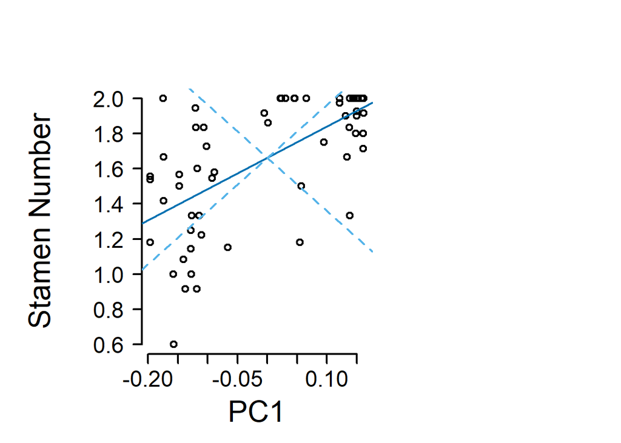

```r
# stamen data
#estimate the confidence intervals
stamenVaest = var0(stamenQpc$cml)
stamenCI = 1.96*sqrt(stamenVaest*stamenEig$values)

#plot
par(mar = c(5,8,5,14), xpd=T)

plot(stamenEig$vectors[,1], stamenTrait$Pheno[-nrow(stamenTrait)], bty="n", lwd=2, ylab = "", yaxt="n",xlab = "PC1", cex.lab=2, cex.axis=2, xaxt="n")
axis(1, cex.axis=1.5, lwd=2)
axis(2, las=2, cex.axis=1.5, lwd=2)
mtext('Stamen Number',side=2, line=5, cex=2)
par(xpd=F)
abline(lm(stamenTrait$Pheno[-nrow(stamenTrait)]~stamenEig$vectors[,1]), lwd=2, col = "#0072B2")
abline(a=mean(stamenTrait$Pheno), b = stamenCI[1], lty=2, col='#56B4E9', lwd=2)
abline(a=mean(stamenTrait$Pheno), b = -stamenCI[1], lty=2, col='#56B4E9', lwd=2)
```

# Plottin

Let’s make a fancy plot cause I like those and it’ll fit with the rest of the manuscript figures.

Set to not evaluate while I figure out some coloring stuff. The last population is not included the y axis. why not? this plotting is kinda confusing to me. and it makes lining things up a bit confusing, but I suppose I can just use the same subsetting that Emily used to remove the last row?

Fixed?

```r
# let's also add elevation for plotting later on - just add this to stamenTrait
load(file = "C:/Users/Sophie/Michigan State University/Conner, Jeffrey - SophieAnalyses/R_script/StamenLossPipeline/Elev_Means_Feb2022.ROBJ")
# don't need the pop mean columns.
Elev_Means <- Elev_Means[ , c('Population', 'Elev_m')]
# make Pop column to merge by
stamenTrait$Population <- substr(stamenTrait$LineID, 1, 3)
# change ARB to ARU
stamenTrait[stamenTrait$Population == "ARB", "Population"] <- "ARU"
# change SPE to SAL
stamenTrait[stamenTrait$Population == "SPE", "Population"] <- "SAL"
# dataframe with x and y vars while still int he same order
forplot <- data.frame("eig_vec1" = stamenEig$vectors[,1], stamenTrait[-nrow(stamenTrait), ])
# join together, need to remove the last row cause Emily does in her plot
forplot <- merge(forplot, Elev_Means, by = "Population")

# prep the dataframe now
# order
forplot <- forplot[order(forplot$Elev_m),]
forplot$Population <- factor(forplot$Population, levels = unique(forplot$Population[order(forplot$Elev_m)]))
str(forplot$Population)
```

```
##  Factor w/ 16 levels "RAB","PIN","SAL",..: 1 1 1 1 2 2 2 2 3 3 ...
```

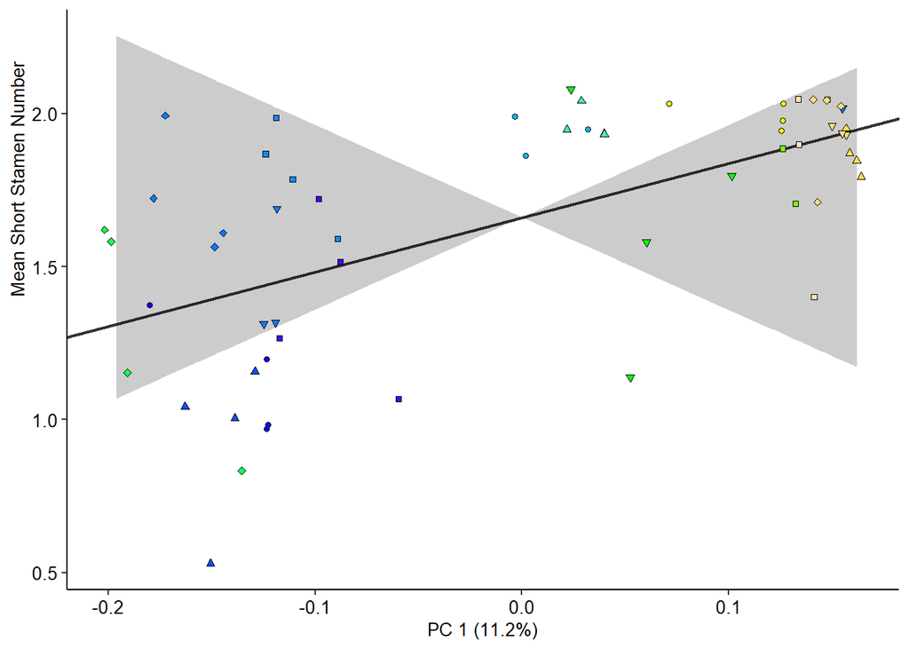

```r
### key is that you need to order the whole sheet AND reorder the factor. BOTH, not just one.
forplot$labels <- paste0(forplot$Population, " - ", forplot$Elev_m, "m")
forplot$posCI <- sapply(forplot$eig_vec1, FUN = function(x){stamenCI[1]*x + mean(stamenTrait$Pheno)})
forplot$negCI <- sapply(forplot$eig_vec1, FUN = function(x){-stamenCI[1]*x + mean(stamenTrait$Pheno)})

# model to draw line from.
m2 <- lm(forplot$Pheno~ forplot$eig_vec1)

# set.seed cause jitter is random
set.seed(220)

ggplot(forplot)+
  geom_ribbon(aes(eig_vec1, ymin = posCI, ymax = negCI), alpha = 0.25)+
  #geom_line(aes(x=eig_vec1, y=posCI), linetype = "solid",
  #          alpha = 0.3, linewidth = 0.75)+
  #geom_line(aes(x=eig_vec1, y=negCI), linetype = "solid",
  #          alpha = 0.3, linewidth = 0.75)+

  geom_abline(intercept = m2$coefficients[1], slope = m2$coefficients[2], linetype = "solid", alpha = 0.8, linewidth = 0.75)+
  geom_jitter(aes(x = eig_vec1 , y = Pheno, shape = as.factor(Population), fill = Elev_m), width = 0.007, height = 0.1, col = "black", size = 1.3, stroke = 0.5, show.legend = FALSE)+
  labs(x = "PC 1 (11.2%)", y = "Mean Short Stamen Number")+
  scale_fill_gradientn(name = "Elevation", colours = topo.colors(16))+
  scale_shape_manual(name = "Population",
                     labels = unique(forplot$label),
                     values = c(rep(c(22, 21, 24, 23, 25), times = 4)))+
  theme_classic()+
  theme(
    legend.title = element_text(color = "black", size = 12),
    legend.text = element_text(color = "black", size = 12),
    axis.title.y = element_text(color = "black", size = 10, hjust = 0.85),
    axis.title.x = element_text(color = "black", size = 10),
    axis.text = element_text(color = "black", size = 10),
    legend.spacing.y = unit(0.03, "cm"))
```

```r
ggsave(filename ="C:/Users/Sophie/Michigan State University/Conner, Jeffrey - SophieAnalyses/Figures/ManuscriptFigs/Qpc_1_topo.png",
       height = 2.25, width = 2.25, device = "png", dpi = 700)
```